# Homework 4: Binary Classification

Vijay Penmetsa

There are four questions (30 total points) in this assignment. The minimum increment is 1 point. Please type in your answers directly in the R Markdown file. After completion, **successfully** knitr it as an html file. Submit **both** the html file and the R Markdown file via Canvas. Please name the R Markdown file in the following format: LastName_FirstName_HW4.Rmd, e.g. Zhao_Zifeng_HW4.Rmd.

## Adult Income Dataset [30 points]

The adult income dataset contains information about 9755 adults from the 2010 U.S. Census database. The data is stored in `Adult_Income.csv`. It contains 8 variables, `age`, `workclass`, `education_num`, `marital_status`, `capital_gain`, `capital_loss`, `hours_per_week`, and `income_50k`. We would like to build several statistical models to predict `income_50k` (i.e. whether income is higher than 50k or not) of a person with given personal information. The data description is as follows.

- `age`: Age in years
- `workclass`: Type of employment the person has
- `education_num`: Education in years
- `marital_status`: Marital status
- `capital_gain`: Capital gain in the past year
- `capital_loss`: Capital loss in the past year
- `hours_per_week`: Average working hours per week
- `income_50k`: A factor with levels Yes and No indicating whether the income higher than 50k or not

### **Q1 [3 points]** Data Partition

**Q1(a) [1 points]** Let’s correctly read in the data in `Adult_Income.csv` and name it as `total_data`.

```r
## Write code solution to Q1(a) here
rm(list=ls())
total_data <- read.csv("./Adult_Income.csv", header=T, stringsAsFactors=T)
```

```r
str(total_data)
```

[output not shown]

**Q1(b) [2 points]** Let’s partition the data in `total_data` into training **(60%)** and test data **(40%)** and store them as `R` objects `train_data` and `test_data` respectively. Use random seed **`set.seed(7)`**!

```r
## Write code solution to Q1(b) here
set.seed(7)
total_obs <- dim(total_data)[1]

train_data_indices <- sample(1:total_obs, 0.6*total_obs)
train_data <- total_data[train_data_indices,]
test_data <- total_data[-train_data_indices,]

train_obs <- dim(train_data)[1]
```

### **Q2 [8 points]** Logistic Regression and GAM

**Q2(a) [3 points]** Fit a logistic regression model of `income_50k` w.r.t. all 7 predictors using the **training data**, name it `lm1`.

```r
## Write code solution to Q2(a) here
lm1 <- glm(income_50k ~
                 age
               + workclass
               + education_num
               + marital_status
               + capital_gain
               + capital_loss
               + hours_per_week,
               family = 'binomial',
               data = train_data)
summary(lm1)
```

```
##
## Call:
## glm(formula = income_50k ~ age + workclass + education_num +
##     marital_status + capital_gain + capital_loss + hours_per_week,
##     family = "binomial", data = train_data)
##
## Deviance Residuals:
##     Min       1Q   Median       3Q      Max
## -3.9875  -0.5648  -0.2413  -0.0689   3.3202
##
## Coefficients:
##                                       Estimate Std. Error z value Pr(>|z|)
## (Intercept)                         -8.364e+00  4.160e-01 -20.104  < 2e-16 ***
## age                                  2.733e-02  3.498e-03   7.814 5.53e-15 ***
## workclassLocal_gov                  -5.930e-01  2.640e-01  -2.246  0.02469 *
## workclassPrivate                    -5.541e-01  2.266e-01  -2.445  0.01447 *
## workclassSelf_emp_inc               -2.421e-01  2.868e-01  -0.844  0.39859
## workclassSelf_emp_not_inc           -1.240e+00  2.571e-01  -4.822 1.42e-06 ***
## workclassState_gov                  -7.542e-01  2.919e-01  -2.584  0.00978 **
## education_num                        3.493e-01  1.797e-02  19.439  < 2e-16 ***
## marital_statusMarried_civ_spouse     2.200e+00  1.506e-01  14.607  < 2e-16 ***
## marital_statusMarried_spouse_absent -4.551e-01  5.552e-01  -0.820  0.41237
## marital_statusNever_married         -1.979e-01  1.858e-01  -1.065  0.28676
## marital_statusSeparated             -4.533e-01  4.401e-01  -1.030  0.30299
## marital_statusWidowed                3.411e-01  3.044e-01   1.121  0.26250
## capital_gain                         3.097e-04  2.263e-05  13.687  < 2e-16 ***
## capital_loss                         7.343e-04  8.824e-05   8.322  < 2e-16 ***
## hours_per_week                       3.273e-02  3.453e-03   9.478  < 2e-16 ***
## ---
## Signif. codes:  0 '***' 0.001 '**' 0.01 '*' 0.05 '.' 0.1 ' ' 1
##
## (Dispersion parameter for binomial family taken to be 1)
##
##     Null deviance: 6499.6  on 5852  degrees of freedom
## Residual deviance: 4054.4  on 5837  degrees of freedom
## AIC: 4086.4
##
## Number of Fisher Scoring iterations: 7
```

**Q2(b) [5 points]** Fit a GAM of `income_50k` w.r.t. all 7 predictors using the **training data**, name it `gam1`. Let’s use splines with **df=4** for all 5 numerical predictors, which include `age`, `education_num`, `capital_gain`, `capital_loss` and `hours_per_week`.

```r
library(gam)
## Write code solution to Q2(b) here
gam1 <- gam(income_50k ~
                 s(age, df = 4)
               + workclass
               + s(education_num, df = 4)
               + marital_status
               + s(capital_gain, df = 4)
               + s(capital_loss, df = 4)
               + s(hours_per_week, df = 4),
               family = 'binomial',
               data = train_data)
```

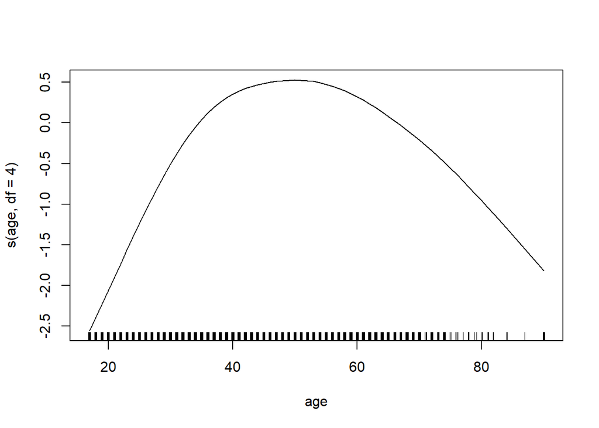

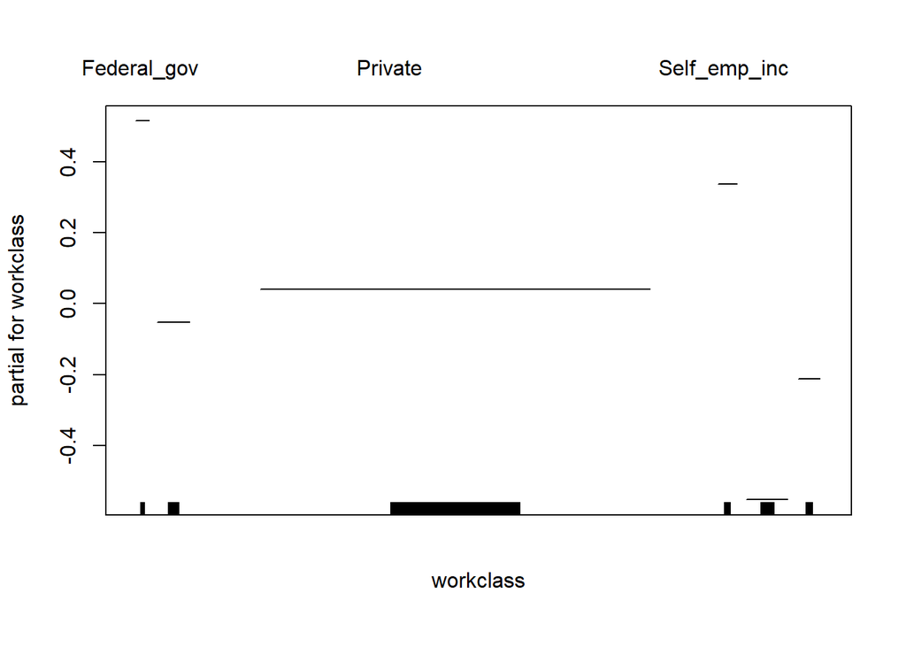

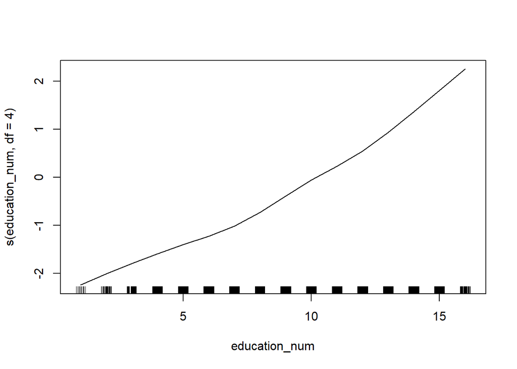

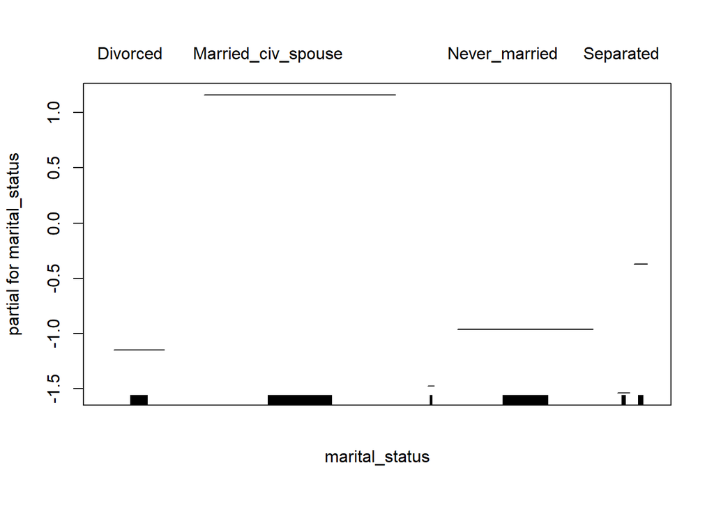

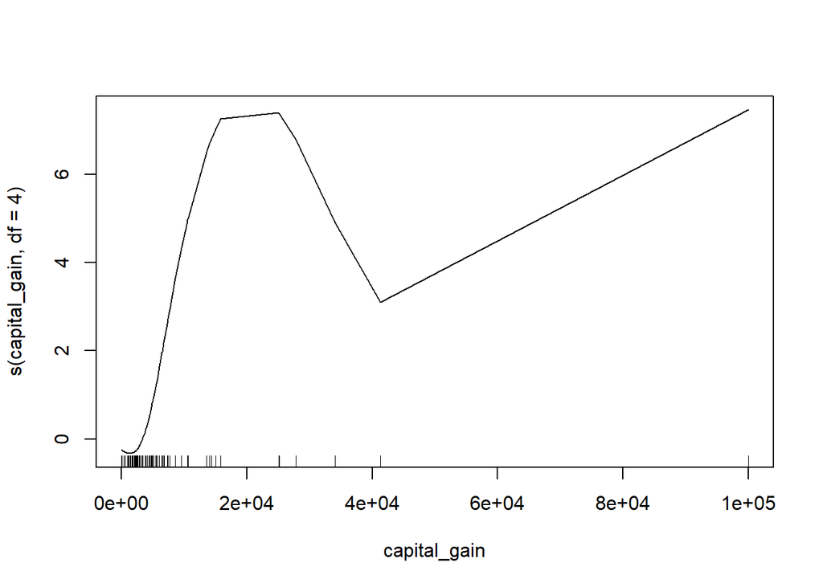

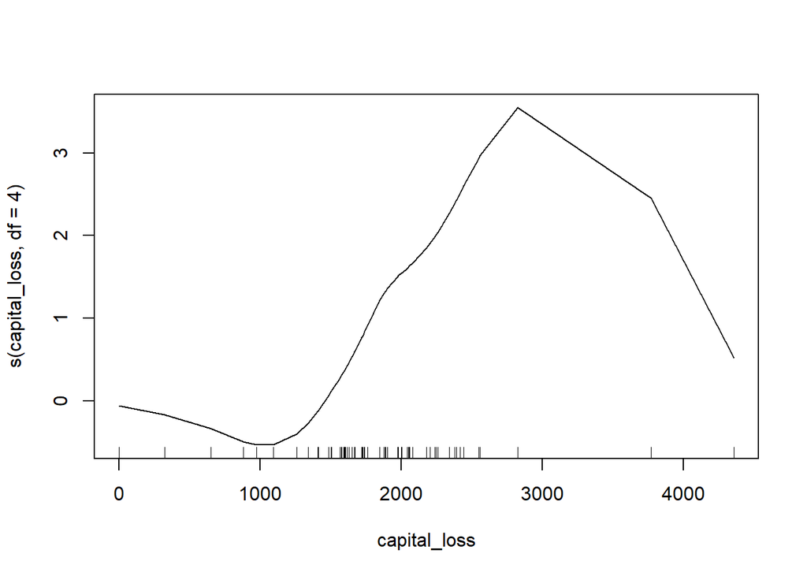

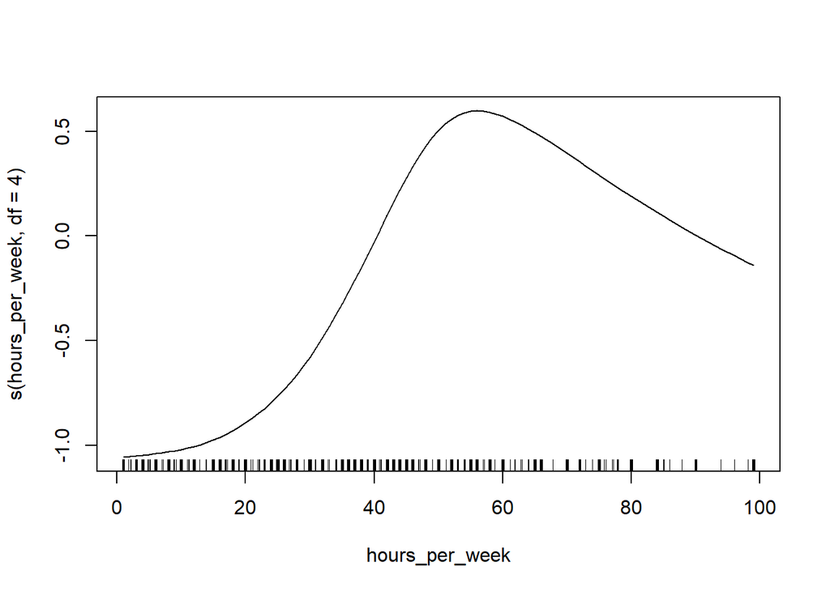

```r
plot(gam1)
```

### **Q3 [9 points]** Neural Networks

Fit an NN of **standardized** `income_50k` w.r.t. all 7 predictors using the **training data**, name it `nn1`. For the architecture of NN, let’s use one hidden layer with 6 hidden units.

**Q3(a) [2 points]** Let’s generate the **training dataset** that are needed for the estimation of NN using the function `model.matrix()` and store it in `x_train_nn`. In addition, use the `scale()` function to standardize the predictors by centering with mean and scaling with sd.

```r
## Write code solution to Q3(a) here
x_train_nn <- model.matrix(~age
               + workclass
               + education_num
               + marital_status
               + capital_gain
               + capital_loss
               + hours_per_week,
               data=train_data)[,-1]

# standardization
x_mean <- apply(x_train_nn, 2, mean)
x_sd <- apply(x_train_nn, 2, sd)
x_train_nn <- scale(x_train_nn, center=x_mean, scale=x_sd)
```

**Q3(b) [1 points]** Let’s further combine the dependent variable `income_50k` with the standardized predictors `x_train_nn` generated in Q3(a).

```r
## Write code solution to Q3(b) here
x_train_nn <- cbind.data.frame(train_data$income_50k, x_train_nn)
colnames(x_train_nn)[1] <- 'income_50k'
```

**Q3(c) [2 points]** Let’s generate the **test dataset** that are needed for the out-of-sample prediction evaluation of NN using the function `model.matrix` and store it in `x_test_nn`. Use the `scale()` function to standardize the predictors by centering with mean and scaling with sd as in Q3(a).

```r
## Write code solution to Q3(c) here
x_test_nn <- model.matrix(~age
               + workclass
               + education_num
               + marital_status
               + capital_gain
               + capital_loss
               + hours_per_week,
               data=test_data)[,-1]

# standardization
x_test_nn <- scale(x_test_nn, center=x_mean, scale=x_sd)
```

**Q3(d) [4 points]** Let’s fit an NN that has one hidden layer with 6 hidden units. Make sure to use random seed **`set.seed(7)`**! Note that since some categorical variables have a number of different levels, for convenience, let’s use the shortcut formula `Y~.` in the function `neuralnet()`. (You can also use the `Y~X1+X2...+Xp` formula if you want.)

```r
## Write code solution to Q3(d) here
library(neuralnet)
set.seed(7)
nn1 <- neuralnet(income_50k=='Yes'~.,
               data=x_train_nn, hidden=c(6), linear.output=F)
```

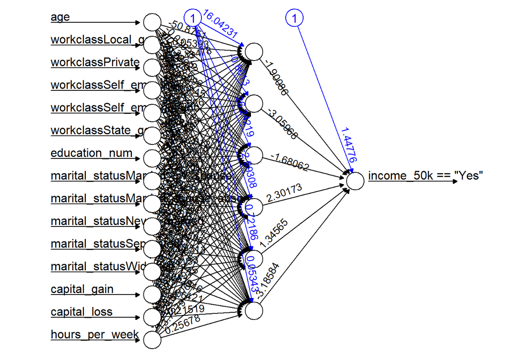

```r
plot(nn1, rep = 'best')
```

### **Q4 [10 points]** Model Evaluation (Prediction)

**Q4(a) [2 points]** Use `lm1`, `gam1` and `nn1` to generate probability predictions for `income_50k` on the test data and store the predicted probability in `lm1_pred`, `gam1_pred` and `nn1_pred` respectively.

```r
## Write code solution to Q4(a) here
lm1_pred <- predict(lm1, newdata = test_data, type = 'response')
gam1_pred <- predict(gam1, newdata = test_data, type = 'response')
nn1_pred <- predict(nn1, newdata = x_test_nn, type = 'response')[,1]
```

**Q4(b) [3 points]** Use the `R` package `caret` to evaluate the prediction performance of `lm1`, `gam1` and `nn1`. What are the TP for `lm1`, `gam1` and `nn1`?

```r
library(caret)
## Write code solution to Q4(b) here

lm1_pred_class <- factor(ifelse(lm1_pred > 0.5, "Yes", "No"))
gam1_pred_class <- factor(ifelse(gam1_pred > 0.5, "Yes", "No"))
nn1_pred_class <- factor(ifelse(nn1_pred > 0.5, "Yes", "No"))


lm1_acc <- confusionMatrix(lm1_pred_class, test_data$income_50k, positive = "Yes")
gam1_acc <- confusionMatrix(gam1_pred_class, test_data$income_50k, positive = "Yes")
nn1_acc <- confusionMatrix(nn1_pred_class, test_data$income_50k, positive = "Yes")

lm1_acc
```

```
## Confusion Matrix and Statistics
##
##           Reference
## Prediction   No  Yes
##        No  2770  387
##        Yes  209  536
##
##                Accuracy : 0.8473
##                  95% CI : (0.8356, 0.8584)
##     No Information Rate : 0.7635
##     P-Value [Acc > NIR] : < 2.2e-16
##
##                   Kappa : 0.547
##
##  Mcnemar's Test P-Value : 4.161e-13
##
##             Sensitivity : 0.5807
##             Specificity : 0.9298
##          Pos Pred Value : 0.7195
##          Neg Pred Value : 0.8774
##              Prevalence : 0.2365
##          Detection Rate : 0.1374
##    Detection Prevalence : 0.1909
##       Balanced Accuracy : 0.7553
##
##        'Positive' Class : Yes
##
```

```r
gam1_acc
```

```
## Confusion Matrix and Statistics
##
##           Reference
## Prediction   No  Yes
##        No  2799  391
##        Yes  180  532
##
##                Accuracy : 0.8537
##                  95% CI : (0.8422, 0.8646)
##     No Information Rate : 0.7635
##     P-Value [Acc > NIR] : < 2.2e-16
##
##                   Kappa : 0.5601
##
##  Mcnemar's Test P-Value : < 2.2e-16
##
##             Sensitivity : 0.5764
##             Specificity : 0.9396
##          Pos Pred Value : 0.7472
##          Neg Pred Value : 0.8774
##              Prevalence : 0.2365
##          Detection Rate : 0.1363
##    Detection Prevalence : 0.1825
##       Balanced Accuracy : 0.7580
##
##        'Positive' Class : Yes
##
```

```r
nn1_acc
```

```
## Confusion Matrix and Statistics
##
##           Reference
## Prediction   No  Yes
##        No  2756  382
##        Yes  223  541
##
##                Accuracy : 0.845
##                  95% CI : (0.8332, 0.8562)
##     No Information Rate : 0.7635
##     P-Value [Acc > NIR] : < 2.2e-16
##
##                   Kappa : 0.5436
##
##  Mcnemar's Test P-Value : 1.331e-10
##
##             Sensitivity : 0.5861
##             Specificity : 0.9251
##          Pos Pred Value : 0.7081
##          Neg Pred Value : 0.8783
##              Prevalence : 0.2365
##          Detection Rate : 0.1386
##    Detection Prevalence : 0.1958
##       Balanced Accuracy : 0.7556
##
##        'Positive' Class : Yes
##
```

Answer: The TP for `lm1`, `gam1` and `nn1` are 536, 532, and 541, respectively.

**Q4(c) [1 points]** Which statistical model has the best sensitivity, `lm1` or `gam1` or `nn1`? Give the model and the corresponding sensitivity value.

Answer:

nn1 has the best sensitivity

lm1 - 0.5807  
gam1 - 0.5764  
nn1 - 0.5861

**Q4(d) [2 points]** Use the `R` package `caret` to generate the lift charts of `lm1`, `gam1` and `nn1`. Make sure to set the `cuts` argument in the `lift()` function as **`cuts=100`** to save computational time.

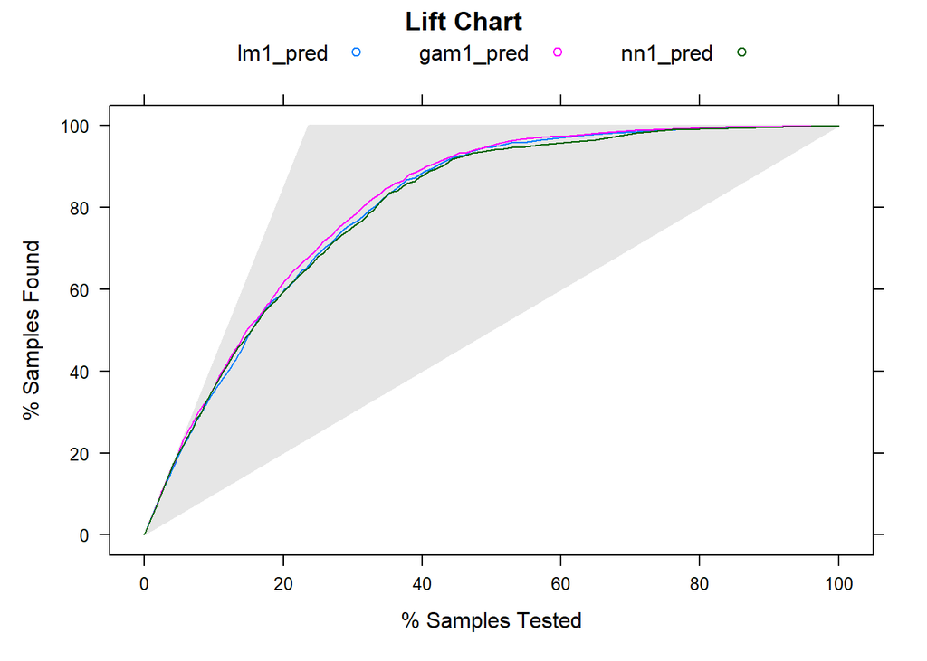

```r
## Write code solution to Q4(d) here
lift_chart <- lift(test_data$income_50k~lm1_pred+gam1_pred+nn1_pred, class='Yes',cuts = 100)
xyplot(lift_chart, auto.key=list(columns=3), main='Lift Chart')
```

**Q4(e) [2 points]** Based on the lift chart, which statistical model ,performs the best in terms of identifying people with income > 50k?

Answer: As per the lift chart, gam1 has the best performance in terms of identifying people with income greater than 50k.